# GLM para dados binários

Maria Carolina Pacheco

## 1 Introdução

Dados binários são caracterizados por variáveis que podem assumir apenas dois estados possíveis (0-1). Para este relatório, utilizarei dados de um experimento de estresse térmico realizado com corais, de modo que minha variável resposta será a ocorrência de braqueamento nesses corais. Os corais serão classificados como branqueados (1) ou saudáveis (0).

```r
#IMPORTANDO OS E COMEÇANDO A EXPLORAR OS DADOS

# abrir meu banco de dados
micro_sid <- read.csv("dados_scriptsR/geral_microhabitat_sid.csv", header = T, sep =";", dec = ".")

# começar a explorar a estrutura os dados
str(micro_sid)
```

```
## 'data.frame':    1351 obs. of  13 variables:
##  $ data       : chr  "09/12/2024" "09/12/2024" "09/12/2024" "09/12/2024" ...
##  $ dia_exp    : int  0 0 0 0 0 0 0 0 0 0 ...
##  $ temp       : num  27.7 27.7 27.7 27.7 27.7 ...
##  $ temp_excess: num  0 0 0 0 0 0 0 0 0 0 ...
##  $ dhw        : num  0 0 0 0 0 0 0 0 0 0 ...
##  $ trat       : chr  "C" "C" "C" "C" ...
##  $ sist       : int  1 1 1 1 1 1 2 2 2 2 ...
##  $ id         : chr  "TA1" "BK1" "TC1" "TE1" ...
##  $ yii        : num  0.653 0.64 0.669 0.644 0.623 0.657 0.668 0.712 0.714 0.63 ...
##  $ cor        : chr  "D5" "D5" "D4" "D4" ...
##  $ habitat    : chr  "T" "B" "T" "T" ...
##  $ colonia    : chr  "A" "K" "C" "E" ...
##  $ fragmento  : chr  "A1" "K1" "C1" "E1" ...
```

Aqui conseguimos visualizar todas as colunas do banco de dados. Detalhes sobre as que nos interessam: - dia_exp : Tempo do experimento contado em dias

- trat: O tratamento ao qual o coral foi submetido: controle (27°C), aquecido (32°C)
- id: código de identificação de cada coral
- cor: classe de cor do coral, indicando sua saúde. Quando maior o número da classe, melhor é o estado de saúde
- habitat: indica se o coral foi coletado no topo (T) ou na base (B) do recife

## 2 Organizando os dados

Vemos também que algumas das nossas variáveis estão sendo lidas como “character”. Vamos converter para fator:

```r
# converter em fator o que está como character
cols1 <- c("dia_exp","trat", "id", "cor", "habitat", "colonia")
micro_sid[, cols1] <- lapply(micro_sid[, cols1], factor)
```

Como eu quero que meu y seja a incidência de branqueamento nos corais, vou usar a coluna “cor” e considerar as cores D1 e D2 como branqueamento:

```r
# checando quais categorias de cor eu tenho:
table(micro_sid$cor)
```

```
##
##    D1    D2    D3    D4    D5    D6    E5 morto
##    91   154   314   510   248    27     1     2
```

```r
# Convertendo as classes em branqueado x saudável
micro_sid <- micro_sid %>%
  filter(cor != "morto") %>% #vou desconsiderar os corais que morreram, já que quero dados binomiais
  mutate (branq = if_else(cor %in% c("D1", "D2"), 1, 0)) # o que for D1 ou D2 vai passar a ser 1, significando que branqueou

# Convertendo essa coluna nova em fator
micro_sid$branq <- as.factor(micro_sid$branq)
```

## 3 Análise exploratória

Agora vamos começar a plotar os dados em gráficos para tentar visualizar padrões e a estrutura dos dados:

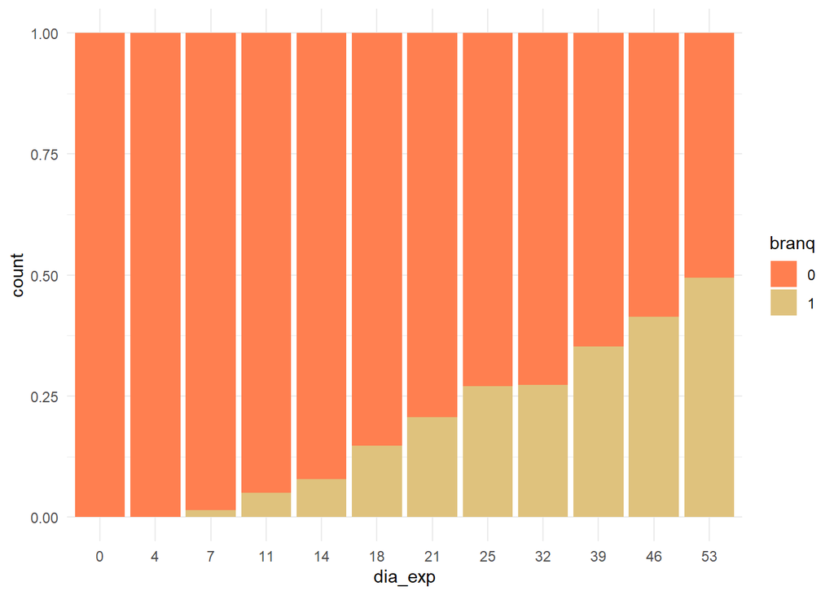

```r
# Proporção de branqueamento ao longo do tempo
ggplot(micro_sid, aes(x = dia_exp, fill = branq)) +
  geom_bar(position = "fill") +
  scale_fill_manual(values = c("coral", "#dfc27d"))+
  theme_minimal()
```

Vemos aqui que a proporção de branqueamento aumenta ao longo do experimento. Agora vamos começar a plotar o efeito das nossas variáveis preditoras, que são o tratamento (Controle e Aquecido) e o habitat de origem (Topo e Base).

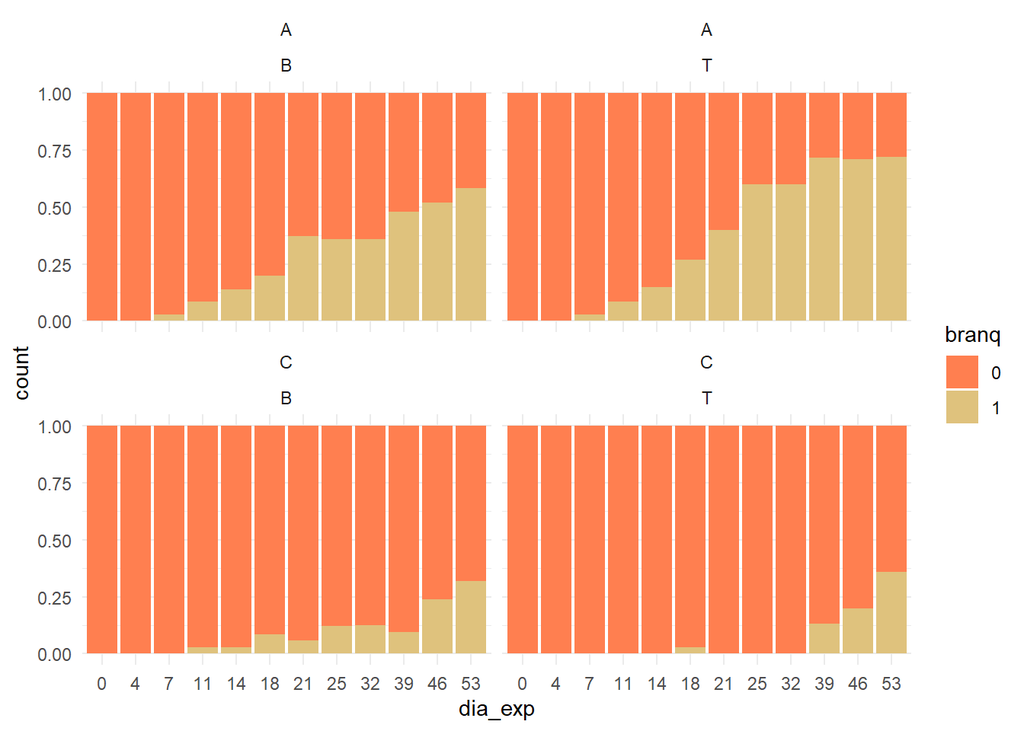

```r
ggplot(micro_sid, aes(x = dia_exp, fill = branq)) +
  geom_bar(position = "fill") +
  scale_fill_manual(values = c("coral", "#dfc27d"))+
  facet_wrap(trat ~ habitat) +
  theme_minimal()
```

Os corais aquecidos parecem apresentar maior proporção de branqueamento ao longo do tempo do que os do tratamento controle, o que é esperado. Apesar disso, ainda parece ter ocorrido um pequeno efeito da manipulação nos controles.

**Esses dados envolvem medidas repetidas, já que foram coletados repetidas vezes nas mesmas colônias de coral o longo do tempo. Por isso, pra este relatório, vou selecionar apenas o dia 32 (1 semana após o fim do estresse termico).**

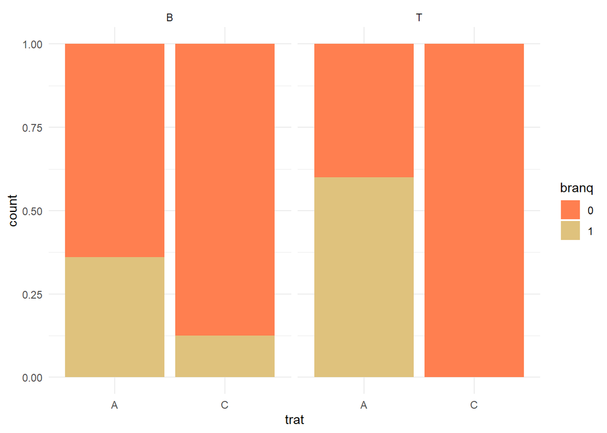

```r
# Selecionando os dados do dia 32
d32 <- micro_sid %>%
  filter(dia_exp==32)

# Plotando apenas os dados do dia 32
ggplot(d32, aes(x=trat, fill = branq))+
  geom_bar(position = "fill")+
  scale_fill_manual(values = c("coral", "#dfc27d"))+
  facet_wrap(.~ habitat) +
  theme_minimal()
```

Parece que os corais do topo do recife branquearam mais que os corais da base e que houve um efeito do tratamento de aquecimento. Vamos rodar os modelos para testar estatísticamente.

## 4 Criando os modelos

A princípio, vou montar os modelos utilizando apenas os dados do dia 32.

```r
# Modelo nulo
mod0 <- glm(branq ~ 1,
            family = binomial(link = "logit"),
            data = d32)

# Só com o efeito do tratamento
mod1 <- glm(branq ~ trat,
            family = binomial(link = "logit"),
            data = d32)

# Com o efeito do tratamento + micro-habitat
mod2 <- glm(branq ~ trat + habitat,
            family = binomial(link = "logit"),
            data = d32)

# Agora com o efeito da interação entre tratamento e micro-habitat
mod3 <- glm(branq ~ trat*habitat,
            family = binomial(link = "logit"),
            data = d32)

# Comparar os modelos usando AIC
aic <- AIC(mod0, mod1, mod2, mod3)
aic %>% arrange(-AIC)
```

```
##      df       AIC
## mod0  1 118.01862
## mod2  3  97.24027
## mod1  2  95.80640
## mod3  4  92.40646
```

O modelo 3, que inclui a interação entre o tratmento e o habitat de origem dos corais, foi o que teve o menor AIC e, portanto, melhor explicou os nossos dados.

## 5 Validação do modelo

Agora vou validar o ajuste do modelo escolhido, que foi o 3, por meio da análise dos resíduos.

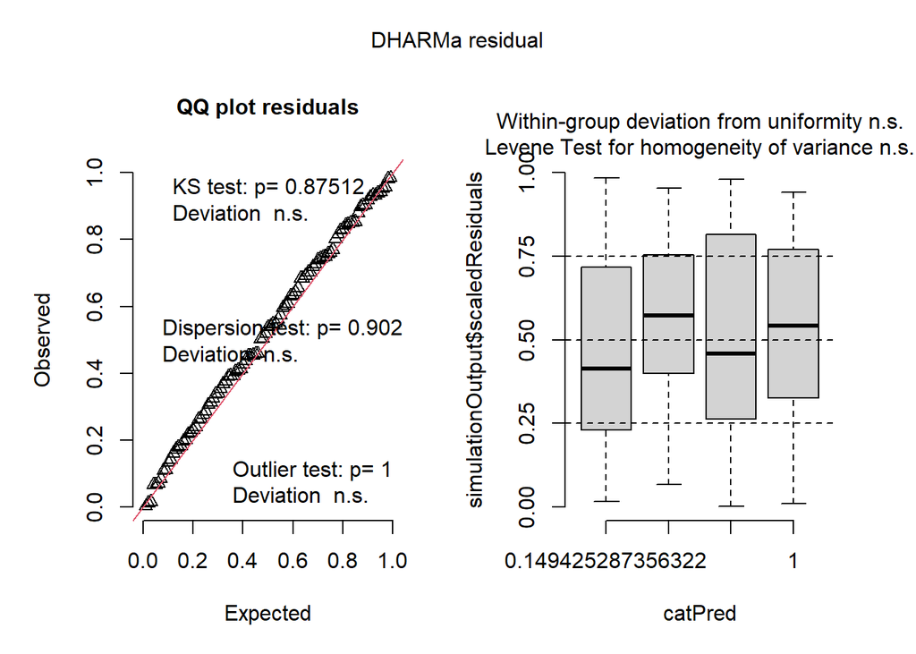

```r
# Simular os resíduos
resid_sim <- simulateResiduals(mod3, n=1000)

# Plotar os resíduos
plot(resid_sim) # Parece estar tudo ok, nada deu significativo
```

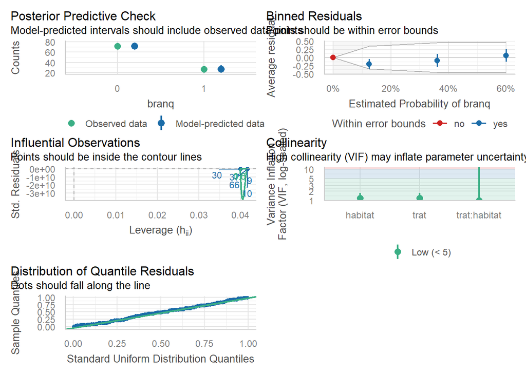

```r
# Outra maneira de checar
check_model(mod3) # Parece que o modelo está conseguindo prever bem os dados, considerando que os dados observados estão bem próximos do predito.
```

## 6 Visualização e interpretação dos resultados

```r
summary(mod3)
```

```
##
## Call:
## glm(formula = branq ~ trat * habitat, family = binomial(link = "logit"),
##     data = d32)
##
## Coefficients:
##                 Estimate Std. Error z value Pr(>|z|)
## (Intercept)      -0.5754     0.4167  -1.381   0.1673
## tratC            -1.3705     0.7447  -1.840   0.0657 .
## habitatT          0.9808     0.5833   1.681   0.0927 .
## tratC:habitatT  -17.6010  1304.5280  -0.013   0.9892
## ---
## Signif. codes:  0 '***' 0.001 '**' 0.01 '*' 0.05 '.' 0.1 ' ' 1
##
## (Dispersion parameter for binomial family taken to be 1)
##
##     Null deviance: 116.019  on 98  degrees of freedom
## Residual deviance:  84.406  on 95  degrees of freedom
## AIC: 92.406
##
## Number of Fisher Scoring iterations: 17
```